# Final Report

Author

Adrian Tran, Harshitha Bachina, Hayden King, Josh Shneyder

# Summary of Data

## Data Description

In this final project report, my group and I decided to explore the relationship between the inflation-adjusted GDP per capita in US dollars and the Life Expectancy at birth. We retrieved this data from Gap Minder, which is a data source that combines data from multiple sources into a coherent time series. The Life Expectancy data set shows the average number of years a newborn child would live if current mortality rates stay the same. The data set ranges across various countries and includes rates from 1799 to 2099. The inflation-adjusted GDP per capita in US dollars covers various countries as well from 1959 to 2019. We joined these data sets together to analyze the relationship between GDP per capita and Life Expectancy between 1959 and 2019.

This project often utilizes the $R^2$ value as a comparative measure for goodness of fit for a given model. This statistical measure determines the variation of a dependent variable that can be explained by an independent variable. A higher $R^2$ signifies a stronger relationship between the two variables.

## Linear Visualization

To visualize the relationship between these variables, we started with a scatterplot.

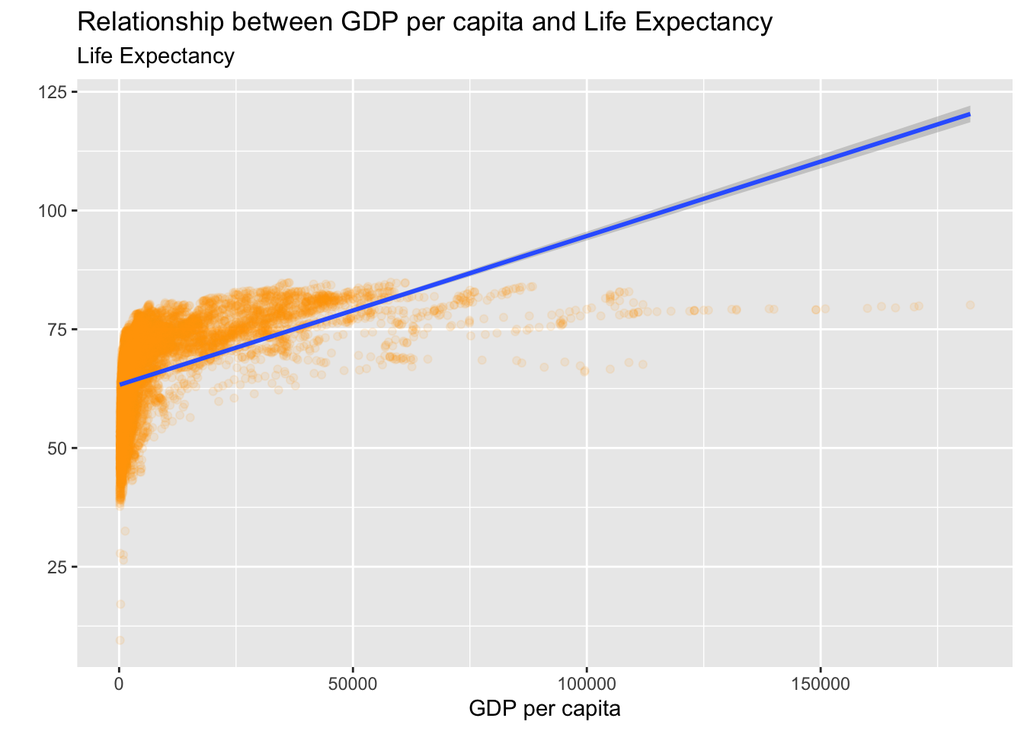

```r
ggplot(data = joined_data, aes(x = GDP, y = Life_Expectancy)) +
  geom_point(alpha = 0.1, color = "orange") +
  labs(
    x = "GDP per capita",
    y = "",
    subtitle = "Life Expectancy",
    title = "Relationship between GDP per capita and Life Expectancy"
  ) +
  geom_smooth(method = "lm")
```

The relationship between $GDP$ and $LifeExpectancy$ is approximately logarithmic, so we did a log transformation of $GDP$. We called the new variable $lGDP$.
$$lGDP = ln(GDP)$$

## Logarithmic Visualization

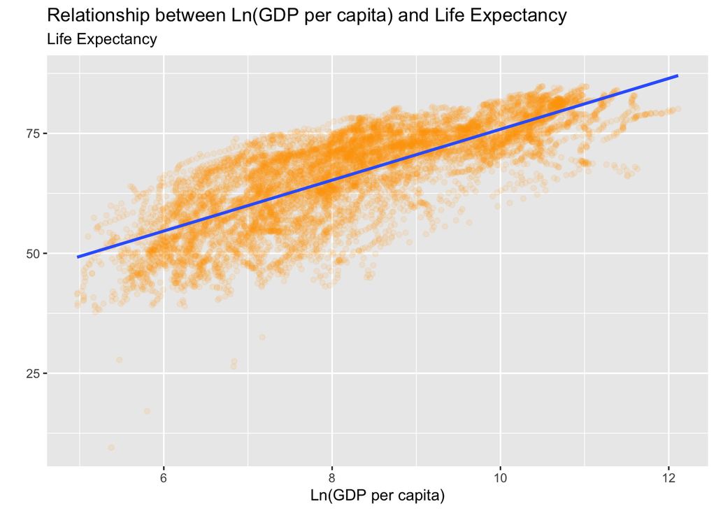

```r
lineargraph = ggplot(data = joined_data, aes(x = lGDP, y = Life_Expectancy)) +
  geom_point(alpha = 0.1, color = "orange") +
  labs(
    x = "Ln(GDP per capita)",
    y = "",
    subtitle = "Life Expectancy",
    title = "Relationship between Ln(GDP per capita) and Life Expectancy"
  ) +
  geom_smooth(method = "lm")
lineargraph
```

```r
logmodel = lm(Life_Expectancy ~ lGDP, data = joined_data)
tidy(logmodel)
```

```
# A tibble: 2 × 5
  term        estimate std.error statistic p.value
  <chr>          <dbl>     <dbl>     <dbl>   <dbl>
1 (Intercept)    22.8     0.372       61.4       0
2 lGDP            5.30    0.0445     119.        0
```

After the transformation, the linear regression line fits the data much better. We will fit a regression line to this transformed data. From here on out, we will examine only the relationship between $lGDP$ and $Life Expectancy$.

# Linear Regression of Transformed Data

## Assumptions of the Linear Regression Model

### 1. Linearity

As shown above, the data still shows some curvature after the log transformation.

### 2. Random Sampling/ No Autocorrelation

The assumption of random sampling isn’t met, but we can substitute the assumption of no autocorrelation. The data shows partial autocorrelation of about 0.2 which is relatively stable across various lags, so this assumption isn’t met either.

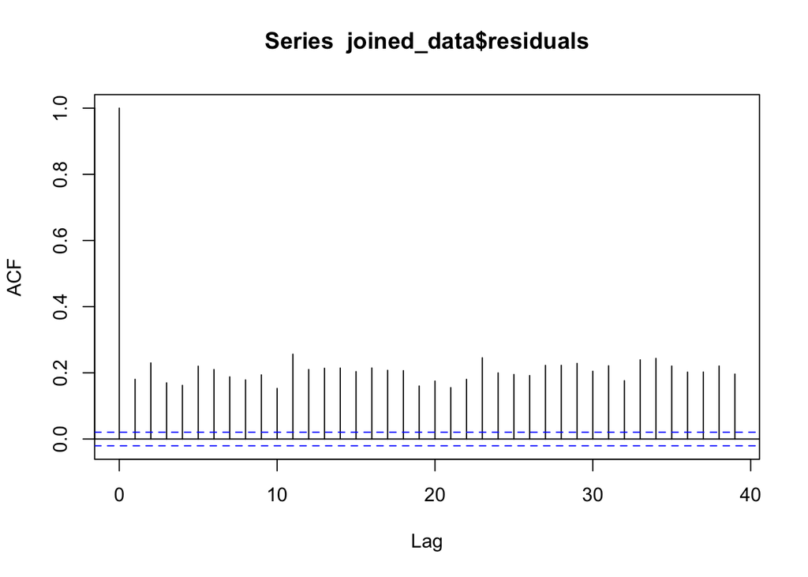

```r
joined_data <- joined_data |>
  mutate(residuals = logmodel$residuals)
acf(joined_data$residuals, type = "correlation")
```

```r
library(lmtest)
```

The Durbin Watson test gives a p-value of 0 for the autocorrelation, meaning there is certainly autocorrelation in the data.

```r
dwtest(logmodel)
```

```
    Durbin-Watson test

data:  logmodel
DW = 1.6389, p-value < 2.2e-16
alternative hypothesis: true autocorrelation is greater than 0
```

### 3. No colinearity

Since there is only one explanatory variable ($lGDP$), there can’t be any colinearity.

### 4. Homoskedasticity

```r
library(AER)
coeftest(logmodel, vcovHC(logmodel))
```

```
t test of coefficients:

            Estimate Std. Error t value  Pr(>|t|)
(Intercept) 22.84047    0.37353  61.147 < 2.2e-16 ***
lGDP         5.30161    0.04237 125.127 < 2.2e-16 ***
---
Signif. codes:  0 '***' 0.001 '**' 0.01 '*' 0.05 '.' 0.1 ' ' 1
```

```r
bptest(logmodel)
```

```
    studentized Breusch-Pagan test

data:  logmodel
BP = 301.4, df = 1, p-value < 2.2e-16
```

$$BP = n \times R^2_{\hat u^2} = 301.4$$
$$9162 \times R^2_{\hat u^2} = 301.4$$
$$R^2_{\hat u^2} = 0.033$$
While the data isn’t homoskedastic, the Breusch-Pagan test statistic shows that only 3.3% of the variance in $u_i$ can be explained by the variance in $lGDP$. We can say this because $var(u_i) = E(u^2_i) - E(u_i)^2$ and $E(u_i)=0$. While this heteroskedasticity is very much present with a p-value of 0, that is more a function of the huge sample size than a significant amount of the variation in $u^2$ being explained by $lGDP$. The relationship can be seen below. The regression line has a low $R^2$ of 0.033.

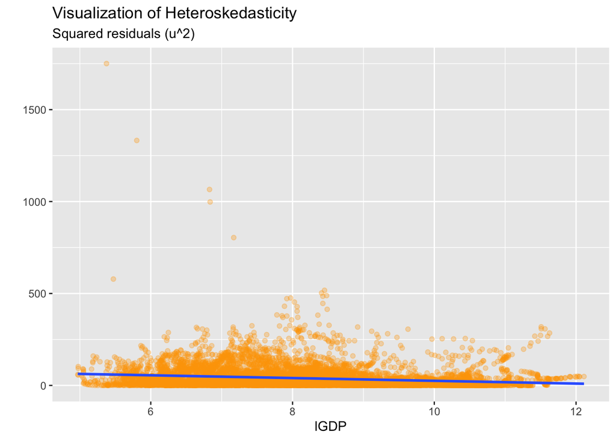

```r
ggplot(data = joined_data, aes(x = lGDP, y = residuals ^ 2,)) +
  geom_point(alpha=0.3, color="orange") +
  geom_smooth(method = "lm") +
  labs(x="lGDP", y="", subtitle="Squared residuals (u^2)", title = "Visualization of Heteroskedasticity")
```

### 5. Normality of $u$

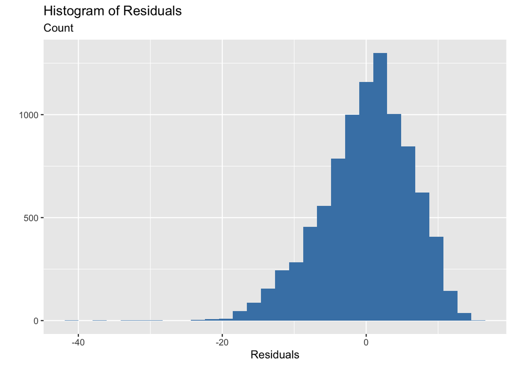

```r
ggplot(data = joined_data, aes(x = residuals)) +
  geom_histogram(fill = "steelblue") +
  labs(
    y = "",
    subtitle = "Count",
    x = "Residuals",
    title = "Histogram of Residuals"
  )
```

## Model Fit

```r
variance_table = matrix(nrow = 1, ncol = 3)
colnames(variance_table) = c("Variance of Response",
                             "Response of Fitted Values",
                             "Variance of Residuals")
variance_table[1, 1] = var(joined_data$Life_Expectancy)
variance_table[1, 2] = var(logmodel$fitted.values)
variance_table[1, 3] = var(logmodel$residuals)
variance_table[1,] = round(variance_table[1,], digits = 2)
kable(variance_table) |>
  kable_material_dark()
```

| Variance of Response | Response of Fitted Values | Variance of Residuals |
| --- | --- | --- |
| 97.63 | 59.34 | 38.29 |

$$R^2 = 1-\frac{38.29}{97.63} = \frac{59.34}{97.63} = 0.608$$
The variance in $lGDP$ accounts for 60.7% of the variance in $Life Expectancy$. This is a moderate $R^2$, so this model does a decent job of explaining the response. Considering how many factors may influence $Life Expectancy$, this is a good quality model.

## Changes Over Time

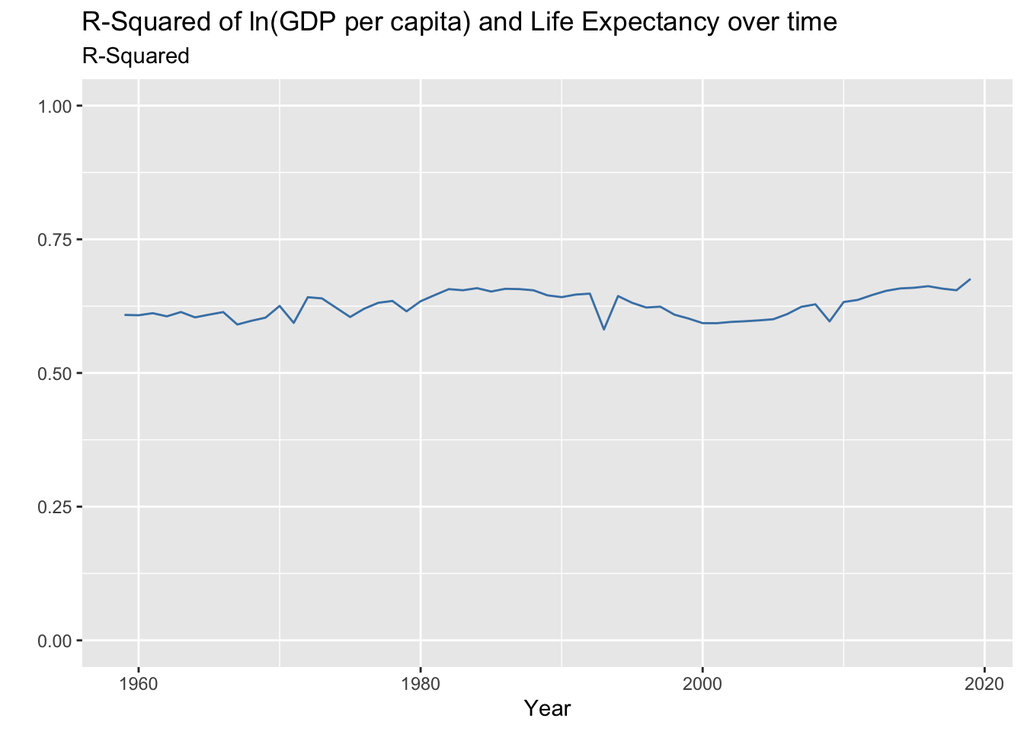

```r
years = 1959:2019
lms_year = matrix(nrow = length(years), ncol = 2)
lms_year[, 1] = years
coef_year = matrix(nrow = length(years), ncol = 3)
coef_year[, 1] = years
for (y in years) {
  year_data = joined_data |>
    filter(Year == y)
  year_model = lm(Life_Expectancy ~ lGDP, data = year_data)
  lms_year[y - 1958, 2] = summary(year_model)$r.squared
  coef_year[y - 1958, 2] = year_model$coefficients[1]
  coef_year[y - 1958, 3] = year_model$coefficients[2]
}
lms_year = data.frame(lms_year)
colnames(lms_year) = c("Year", "Rsquared")
coef_year = data.frame(coef_year)
colnames(coef_year) = c("Year", "Beta0", "Beta1")

ggplot(data = lms_year, aes(x = Year, y = Rsquared)) +
  geom_line(color = "steelblue") +
  ylim(0, 1) +
  labs(y = "",
       subtitle = "R-Squared",
       title = "R-Squared of ln(GDP per capita) and Life Expectancy over time")
```

While variation in $lGDP$ has consistently explained about 60% of variation in $LifeExpectancy$, the nature of this relationship has changed significantly over time.

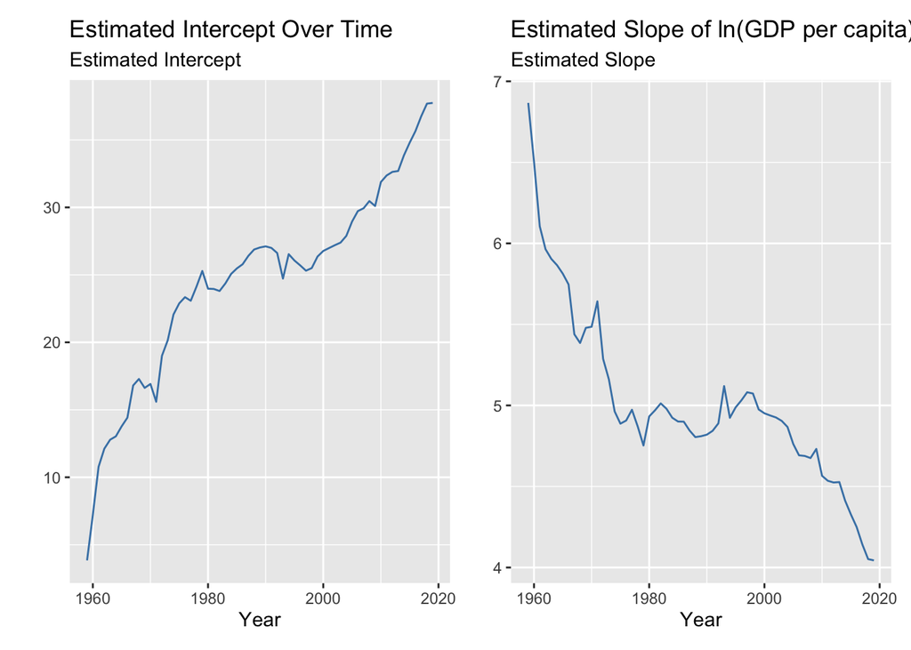

```r
library(patchwork)
beta0 = ggplot(data = coef_year, aes(x = Year, y=Beta0)) +
  geom_line(color = "steelblue") +
  labs(y = "",
       subtitle = "Estimated Intercept",
       title = "Estimated Intercept Over Time")

beta1 = ggplot(data = coef_year, aes(x = Year, y=Beta1)) +
  geom_line(color = "steelblue") +
  labs(y = "",
       subtitle = "Estimated Slope",
       title = "Estimated Slope of ln(GDP per capita) Over Time")
beta0+beta1
```

The first graph shows how the mean $Life Expectancy$ when GDP per capita is 1 dollar has increased dramatically over time. The second graph shows that while a 1% increase in $GDP$ increased $LifeExpectancy$ by almost 0.07 years in 1959, it now does so by only around 0.04 years.

## Differences Between Countries

The relationship between $lGDP$ and $LifeExpectancy$ is pretty stable over time and has been trending upward for the past decade. Outliers can be seen in the noticeable dips in the $R^2$. These low outliers could also be seen on the previous graphs.

### Low Outliers

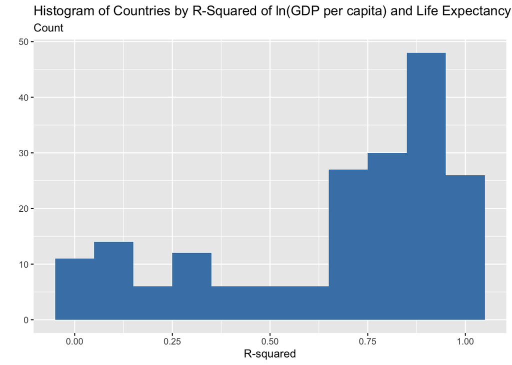

```r
countries = joined_data |>
  select(country) |>
  distinct()

lms_country = matrix(nrow = length(countries), ncol = 2)
lms_country[, 1] = countries
lms_country = data.frame(lms_country)
colnames(lms_country) = c("Country", "Rsquared")
idnum = 1
for (c in countries$country) {
  country_data = joined_data |>
    filter(country == c)
  country_model = lm(Life_Expectancy ~ lGDP, data = country_data)
  lms_country[idnum , "Rsquared"] = summary(country_model)$r.squared
  idnum = idnum + 1
}
ggplot(data = lms_country, aes(x = Rsquared)) +
  geom_histogram(binwidth = 0.1, fill = "steelblue") +
  labs(
    x = "R-squared",
    y = "",
    subtitle = "Count",
    title = "Histogram of Countries by R-Squared of ln(GDP per capita) and Life Expectancy"
  )
```

While the relationship between $lGDP$ and $Life Expectancy$ is quite strong for most countries, for some countries it is much weaker. This is mostly due to events that decrease life expectancy such as epidemics, famines, natural disasters and wars. Botswana for example had a linear relationship between $lGDP$ and $Life Expectancy$ until the AIDS crisis hit. This drop in $Life Expectancy$ while $lGDP$ continued to grow is responsible for its $R^2$ of 0.0013.

```r
outliers <- joined_data |>
  filter(abs(residuals) > 22) |>
  mutate(lGDP = round(lGDP, digits = 2),
         residuals = round(residuals, digits = 2))
kable(
  outliers,
  col.names = c(
    "Year",
    "Country",
    "GDP per Capita",
    "Life Expectancy",
    "ln(GDP per Capita)",
    "Residual"
  )
) |>
  kable_material_dark("hover")
```

| Year | Country | GDP per Capita | Life Expectancy | ln(GDP per Capita) | Residual |
| --- | --- | --- | --- | --- | --- |
| 1959 | Cameroon | 932 | 27.5 | 6.84 | -31.59 |
| 1959 | China | 238 | 27.8 | 5.47 | -24.05 |
| 1960 | Cameroon | 924 | 26.4 | 6.83 | -32.64 |
| 1971 | Burundi | 331 | 17.1 | 5.80 | -36.50 |
| 1993 | Rwanda | 216 | 9.5 | 5.38 | -41.84 |
| 1999 | Botswana | 4570 | 45.5 | 8.43 | -22.02 |
| 2000 | Botswana | 4490 | 45.0 | 8.41 | -22.42 |
| 2001 | Botswana | 4680 | 44.9 | 8.45 | -22.74 |
| 2002 | Botswana | 4820 | 45.7 | 8.48 | -22.10 |
| 2009 | Haiti | 1300 | 32.5 | 7.17 | -28.35 |

These high residual data points are all on the low end. They represent the following events: Cameroonian War of Independence and following Civil War

Great Leap Forward and resulting famine

The AIDS crisis in Southern Africa as seen in Botswana

### Countries with a Weak Relationship

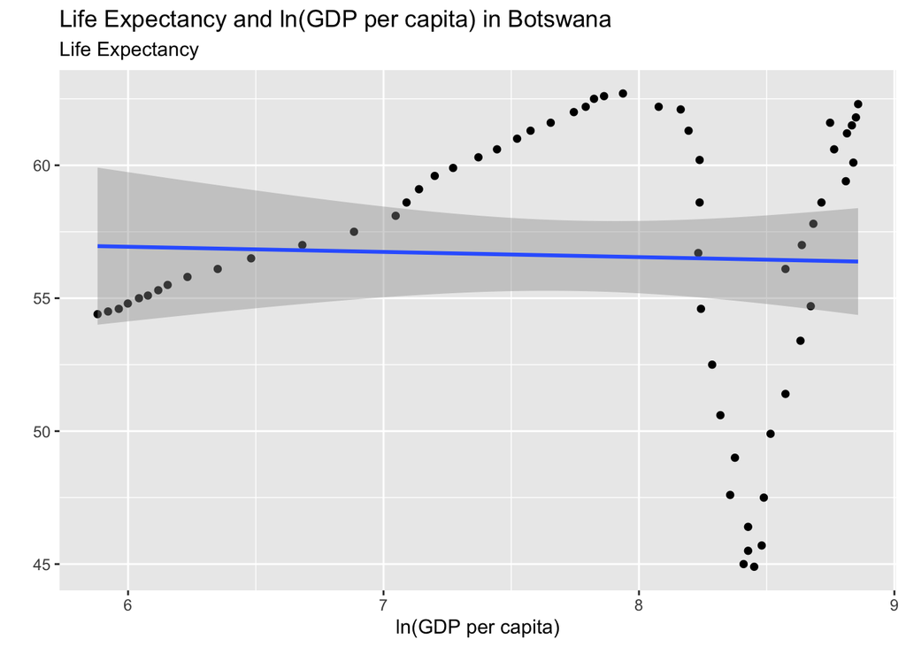

```r
joined_data |>
  filter(country == "Botswana") |>
  ggplot(aes(x = lGDP, y = Life_Expectancy)) +
  geom_point() +
  labs(
    x = "ln(GDP per capita)",
    y = "",
    subtitle = "Life Expectancy",
    title = "Life Expectancy and ln(GDP per capita) in Botswana"
  ) +
  geom_smooth(method = "lm")
```

```r
lms_country |>
  mutate(Rsquared = round(Rsquared, digits = 3)) |>
  slice_min(order_by = Rsquared, n = 8) |>
  kable() |>
  kable_material_dark("hover")
```

| Country | Rsquared |
| --- | --- |
| Liberia | 0.000 |
| Botswana | 0.001 |
| Mauritania | 0.002 |
| Yemen | 0.002 |
| Gambia | 0.003 |
| Sierra Leone | 0.004 |
| Central African Republic | 0.015 |
| Solomon Islands | 0.018 |

### Countries with a Strong Relationship

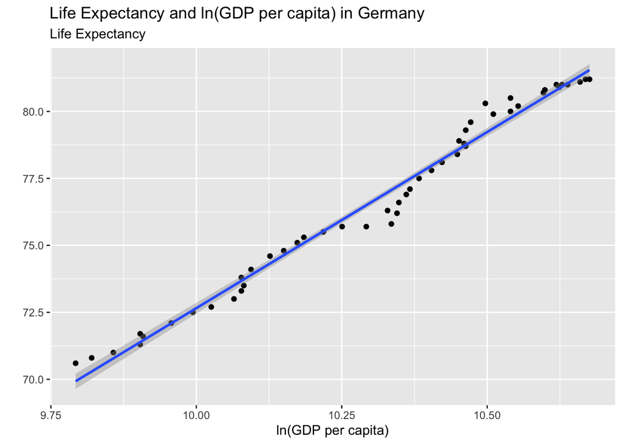

```r
joined_data |>
  filter(country == "Germany") |>
  ggplot(aes(x = lGDP, y = Life_Expectancy)) +
  geom_point() +
  labs(
    x = "ln(GDP per capita)",
    y = "",
    subtitle = "Life Expectancy",
    title = "Life Expectancy and ln(GDP per capita) in Germany"
  ) +
  geom_smooth(method = "lm")
```

In countries without life expectancy-decreasing events since 1959, there is a very strong linear relationship. In the case Germany, the $R^2$ is 0.983.

```r
lms_country |>
  mutate(Rsquared = round(Rsquared, digits = 3)) |>
  slice_max(order_by = Rsquared, n = 8) |>
  kable() |>
  kable_material_dark("hover")
```

| Country | Rsquared |
| --- | --- |
| South Korea | 0.983 |
| Germany | 0.983 |
| Sao Tome and Principe | 0.983 |
| Lao | 0.980 |
| Colombia | 0.978 |
| Hong Kong, China | 0.978 |
| Djibouti | 0.978 |
| Egypt | 0.974 |

## Simuluation

### Simulated Distribution

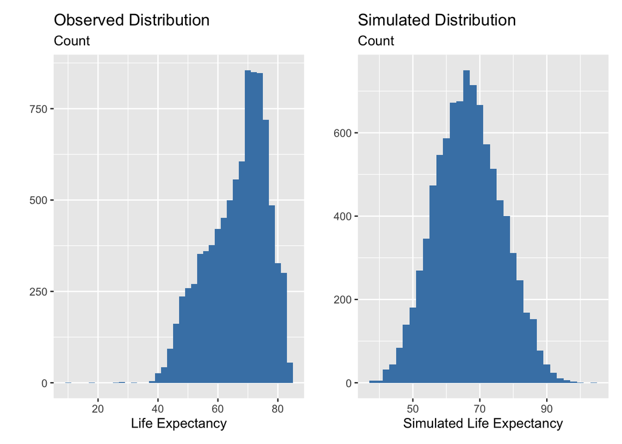

```r
set.seed(1738)
sigma = sigma(logmodel)
predictions = predict(logmodel)
simulation <- function(x, rse) {
  x <- x + rnorm(n = length(x), mean = 0, sd = rse)
  return(x)
}
actualhist = ggplot(data = joined_data, aes(x = Life_Expectancy)) +
  geom_histogram(binwidth = 2, fill = "steelblue") +
  labs(x="Life Expectancy", y="", subtitle = "Count", title="Observed Distribution")
simhist = ggplot(data = joined_data, aes(x = simulation(predictions, sigma))) +
  geom_histogram(binwidth = 2, fill = "steelblue") +
  labs(x="Simulated Life Expectancy", y="", subtitle = "Count", title="Simulated Distribution")
actualhist + simhist
```

Because of the left skew of the data, the simulation distribution doesn’t exactly match the actual distribution. Due to the high sample size (9162 observations,) this isn’t a huge issue.

```r
# simulate <- function() {
#   x = predictions + rnorm(n = length(joined_data$lGDP),
#                           mean = 0,
#                           sd = 6.188)
#   simmodel = lm(joined_data$Life_Expectancy ~ x)
#   return(summary(simmodel)$r.squared)
# }
# ggplot(data = NULL, aes(x = map_dbl(1:2000, ~ simulate()))) +
#   geom_histogram(fill = "steelblue") +
#   labs(
#     x = "Simulated R-squared of Life Expectancy and Simulated ln(GDP per capita)",
#     y = "",
#     subtitle = "Count",
#     title = "R-squared Simulation"
#   )
```

```r
# library(gganimate)
# library(gifski)
# ggplot(data=joined_data, aes(x=lGDP, y=Life_Expectancy, color=country)) +
#   geom_point(alpha = 0.7, show.legend = FALSE) +
#   labs(title = 'Year: {frame_time}', x = 'ln(GDP per capita)', y = 'Life Expectancy') +
#   transition_time(Year) +
#   ease_aes('linear')
```